# VAR_FinalProject

# Final Model

```r
pre_var <- VAR(pre.var, p = 2, type = "both", season = 12)
summary(pre_var)
```

```
##
## VAR Estimation Results:
## =========================
## Endogenous variables: ts.train_pre.import., ts.train_pre.export., ts.train_pre.ppi.
## Deterministic variables: both
## Sample size: 201
## Log Likelihood: 1300.769
## Roots of the characteristic polynomial:
## 0.7315 0.7315 0.5578 0.5424 0.5424 0.1961
## Call:
## VAR(y = pre.var, p = 2, type = "both", season = 12L)
##
##
## Estimation results for equation ts.train_pre.import.:
## =====================================================
## ts.train_pre.import. = ts.train_pre.import..l1 + ts.train_pre.export..l1 + ts.train_pre.ppi..l1 + ts.train_pre.import..l2 + ts.train_pre.export..l2 + ts.train_pre.ppi..l2 + const + trend + sd1 + sd2 + sd3 + sd4 + sd5 + sd6 + sd7 + sd8 + sd9 + sd10 + sd11
##
##                           Estimate Std. Error t value Pr(>|t|)
## ts.train_pre.import..l1 -5.552e-01  6.830e-02  -8.128 6.52e-14 ***
## ts.train_pre.export..l1  1.566e-01  7.058e-02   2.219 0.027750 *
## ts.train_pre.ppi..l1     1.340e+00  3.568e-01   3.754 0.000234 ***
## ts.train_pre.import..l2 -3.527e-01  6.726e-02  -5.244 4.33e-07 ***
## ts.train_pre.export..l2  1.670e-01  7.065e-02   2.364 0.019151 *
## ts.train_pre.ppi..l2     6.580e-01  3.682e-01   1.787 0.075590 .
## const                    9.967e-03  7.706e-03   1.294 0.197477
## trend                   -2.489e-05  6.331e-05  -0.393 0.694673
## sd1                     -4.790e-02  2.229e-02  -2.149 0.032959 *
## sd2                      1.998e-01  2.192e-02   9.115  < 2e-16 ***
## sd3                      1.273e-01  2.464e-02   5.165 6.27e-07 ***
## sd4                      1.352e-01  2.758e-02   4.903 2.08e-06 ***
## sd5                      1.672e-01  2.038e-02   8.205 4.09e-14 ***
## sd6                      1.270e-01  2.071e-02   6.132 5.27e-09 ***
## sd7                      1.190e-01  2.291e-02   5.195 5.45e-07 ***
## sd8                      1.240e-01  2.000e-02   6.197 3.74e-09 ***
## sd9                      1.861e-01  1.906e-02   9.764  < 2e-16 ***
## sd10                     1.228e-01  2.215e-02   5.546 1.02e-07 ***
## sd11                     5.375e-02  2.178e-02   2.468 0.014511 *
## ---
## Signif. codes:  0 '***' 0.001 '**' 0.01 '*' 0.05 '.' 0.1 ' ' 1
##
```

[output cut: 77 more lines]

```
## ts.train_pre.ppi.               5.723e-05            0.0000313
##                      ts.train_pre.ppi.
## ts.train_pre.import.         5.723e-05
## ts.train_pre.export.         3.130e-05
## ts.train_pre.ppi.            1.126e-04
##
## Correlation matrix of residuals:
##                      ts.train_pre.import. ts.train_pre.export.
## ts.train_pre.import.              1.00000              0.09366
## ts.train_pre.export.              0.09366              1.00000
## ts.train_pre.ppi.                 0.10517              0.06239
##                      ts.train_pre.ppi.
## ts.train_pre.import.           0.10517
## ts.train_pre.export.           0.06239
## ts.train_pre.ppi.              1.00000
```

```r
post_var <- VAR(post.var, p = 5, type = "both", season = 12)
summary(post_var)
```

```
##
## VAR Estimation Results:
## =========================
## Endogenous variables: ts.train_post.import., ts.train_post.export., ts.train_post.ppi.
## Deterministic variables: both
## Sample size: 234
## Log Likelihood: 1513.245
## Roots of the characteristic polynomial:
## 0.8311 0.8311 0.7327 0.7327 0.7106 0.7106 0.6984 0.6984 0.6457 0.6457 0.645 0.645 0.6304 0.6304 0.421
## Call:
## VAR(y = post.var, p = 5, type = "both", season = 12L)
##
##
## Estimation results for equation ts.train_post.import.:
## ======================================================
## ts.train_post.import. = ts.train_post.import..l1 + ts.train_post.export..l1 + ts.train_post.ppi..l1 + ts.train_post.import..l2 + ts.train_post.export..l2 + ts.train_post.ppi..l2 + ts.train_post.import..l3 + ts.train_post.export..l3 + ts.train_post.ppi..l3 + ts.train_post.import..l4 + ts.train_pos…
##
##                            Estimate Std. Error t value Pr(>|t|)
## ts.train_post.import..l1 -5.894e-01  6.990e-02  -8.432 5.89e-15 ***
## ts.train_post.export..l1  2.077e-01  7.247e-02   2.866 0.004592 **
## ts.train_post.ppi..l1     9.901e-01  3.321e-01   2.982 0.003210 **
## ts.train_post.import..l2 -4.721e-01  8.147e-02  -5.795 2.54e-08 ***
## ts.train_post.export..l2  3.087e-01  9.115e-02   3.387 0.000847 ***
## ts.train_post.ppi..l2     5.762e-01  3.599e-01   1.601 0.110905
## ts.train_post.import..l3 -1.492e-01  8.849e-02  -1.686 0.093297 .
## ts.train_post.export..l3  1.499e-01  9.978e-02   1.502 0.134512
## ts.train_post.ppi..l3     5.180e-01  3.610e-01   1.435 0.152825
## ts.train_post.import..l4 -1.143e-01  8.056e-02  -1.418 0.157609
## ts.train_post.export..l4  1.155e-01  9.442e-02   1.223 0.222641
## ts.train_post.ppi..l4     6.685e-01  3.597e-01   1.859 0.064477 .
## ts.train_post.import..l5 -5.801e-02  6.760e-02  -0.858 0.391869
## ts.train_post.export..l5  2.601e-02  7.455e-02   0.349 0.727555
## ts.train_post.ppi..l5    -3.960e-01  3.443e-01  -1.150 0.251459
## const                     4.655e-03  7.280e-03   0.639 0.523241
## trend                     2.128e-05  4.994e-05   0.426 0.670410
## sd1                      -5.351e-02  2.315e-02  -2.311 0.021798 *
## sd2                       2.075e-01  2.625e-02   7.905 1.60e-13 ***
## sd3                       1.101e-01  3.085e-02   3.569 0.000446 ***
## sd4                       1.289e-01  3.133e-02   4.115 5.60e-05 ***
## sd5                       1.615e-01  2.450e-02   6.594 3.53e-10 ***
```

[output cut: 104 more lines]

```
## ts.train_post.ppi.                5.139e-05             0.0000278
##                       ts.train_post.ppi.
## ts.train_post.import.          5.139e-05
## ts.train_post.export.          2.780e-05
## ts.train_post.ppi.             1.136e-04
##
## Correlation matrix of residuals:
##                       ts.train_post.import. ts.train_post.export.
## ts.train_post.import.               1.00000                0.1034
## ts.train_post.export.               0.10339                1.0000
## ts.train_post.ppi.                  0.09403                0.0529
##                       ts.train_post.ppi.
## ts.train_post.import.            0.09403
## ts.train_post.export.            0.05290
## ts.train_post.ppi.               1.00000
```

## Check residuals

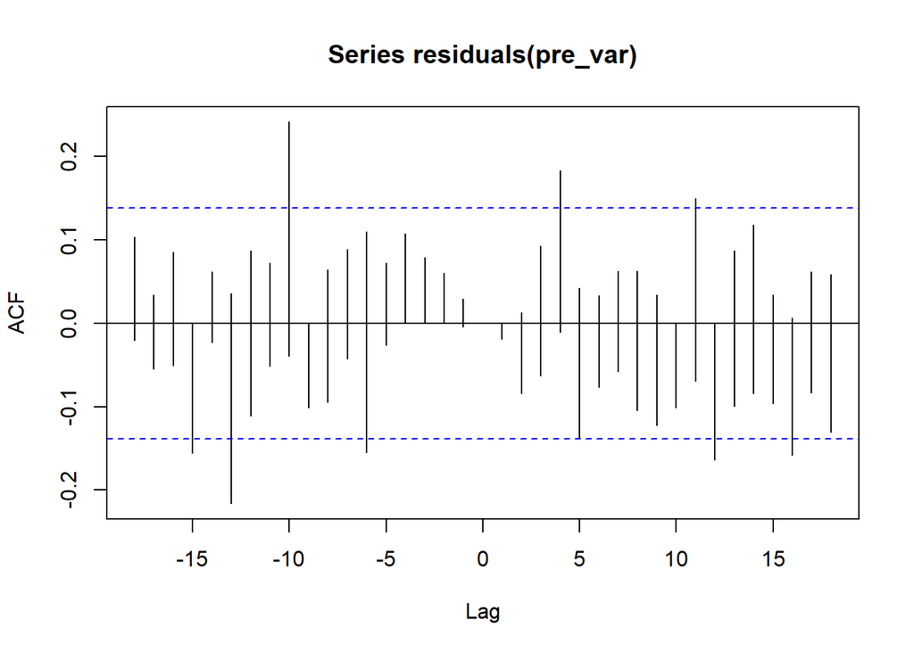

```r
acf(residuals(pre_var))
```

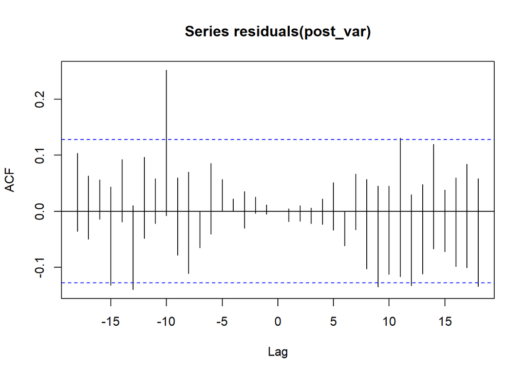

```r
acf(residuals(post_var))
```

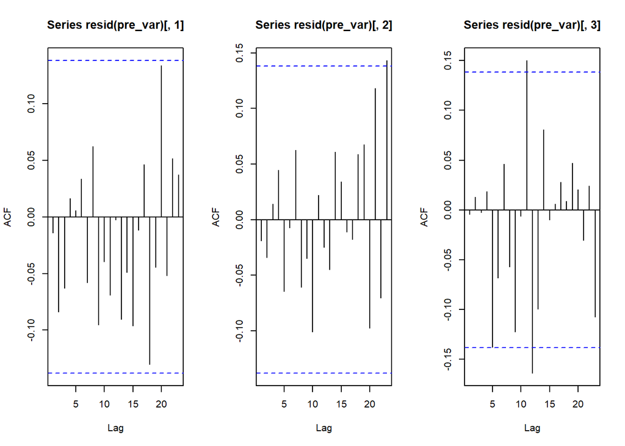

```r
# pre covid
par(mfrow=c(1,3))
acf(resid(pre_var)[, 1])
acf(resid(pre_var)[, 2])
acf(resid(pre_var)[, 3])
```

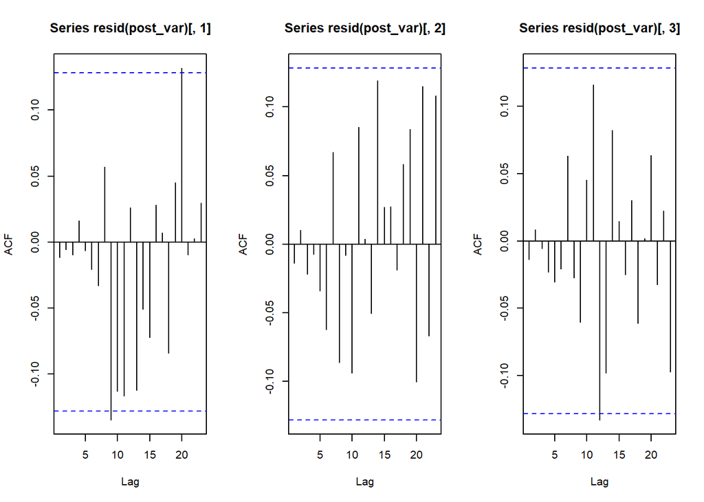

```r
# post covid
par(mfrow=c(1,3))
acf(resid(post_var)[, 1])
acf(resid(post_var)[, 2])
acf(resid(post_var)[, 3])
```

## Forecast Plot

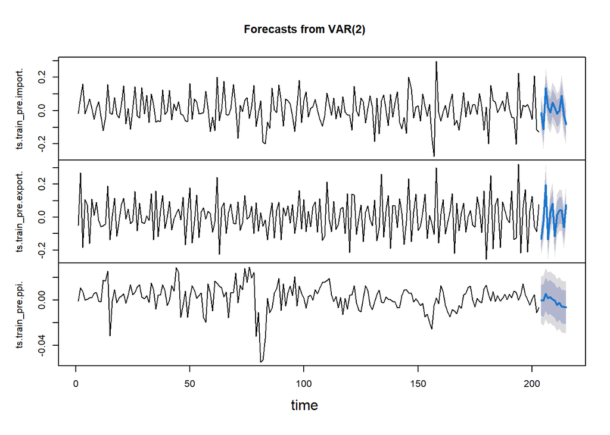

```r
# pre-covid
pre_forecast_data <- predict(pre_var, n.ahead = 12)
pre_impt_forecast <- forecast(pre_var, xreg = pre_forecast_data, h = 12)
plot(pre_impt_forecast)
```

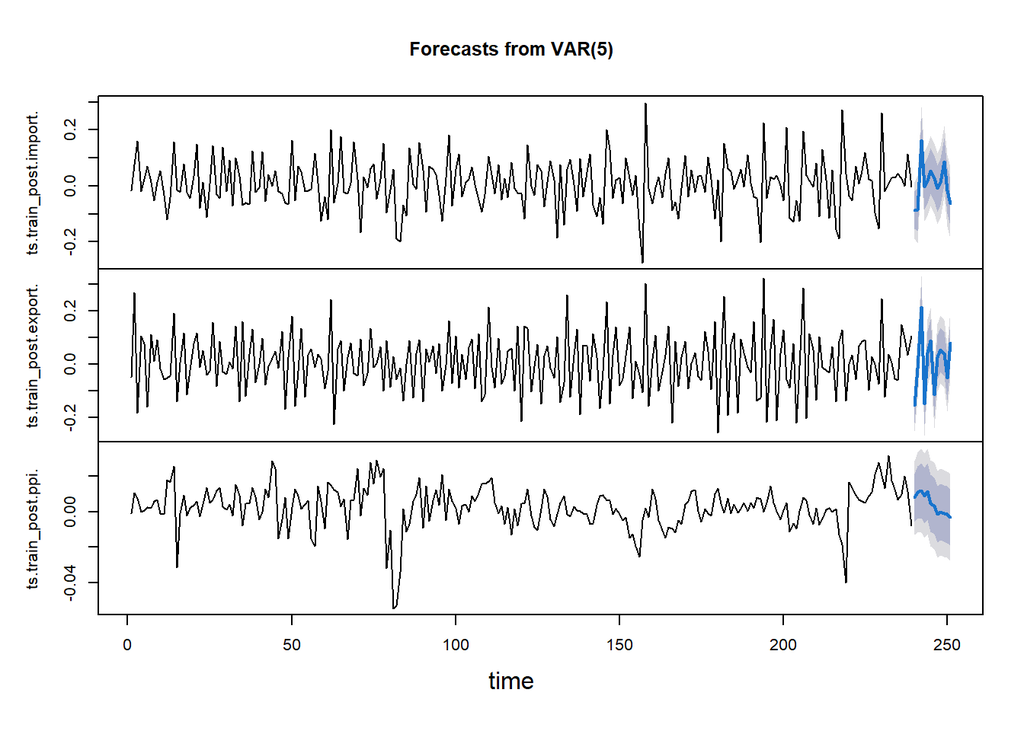

```r
# post-covid
post_forecast_data <- predict(post_var, n.ahead = 12)
post_impt_forecast <- forecast(post_var, xreg = post_forecast_data, h = 12)
plot(post_impt_forecast)
```

## Impulse Response

Reference:

https://www.aptech.com/blog/the-intuition-behind-impulse-response-functions-and-forecast-error-variance-decomposition/

https://spureconomics.com/impulse-response-functions-after-var-and-vecm/

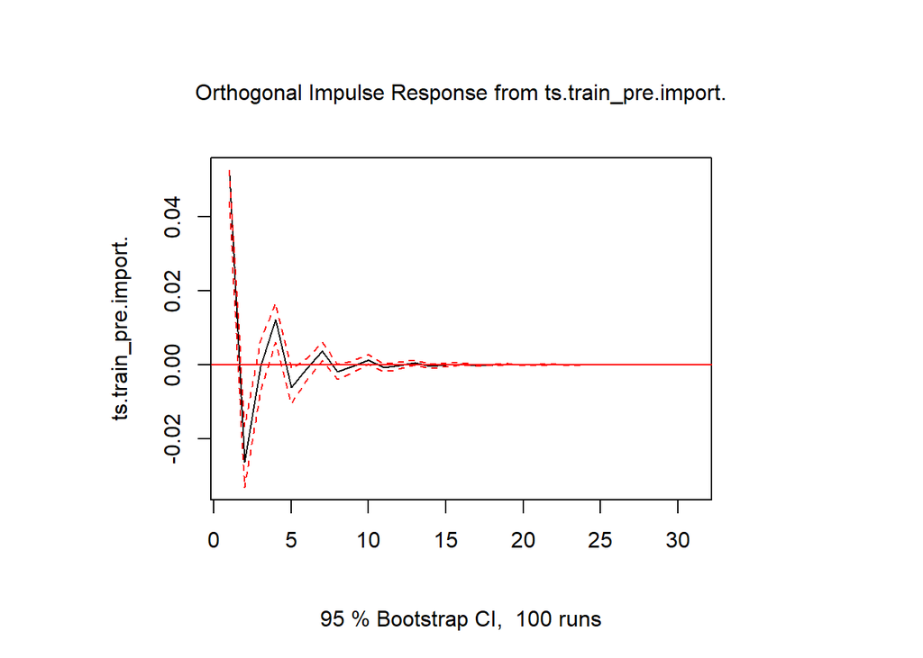

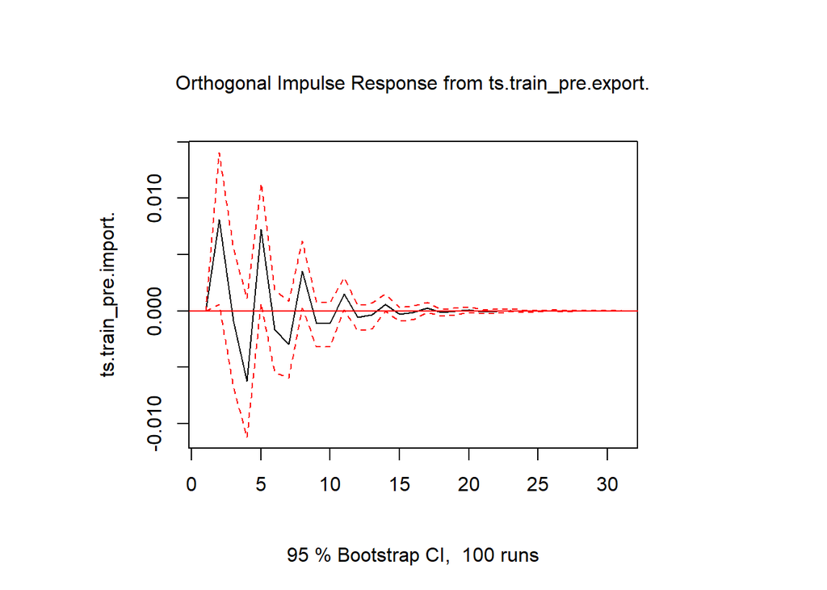

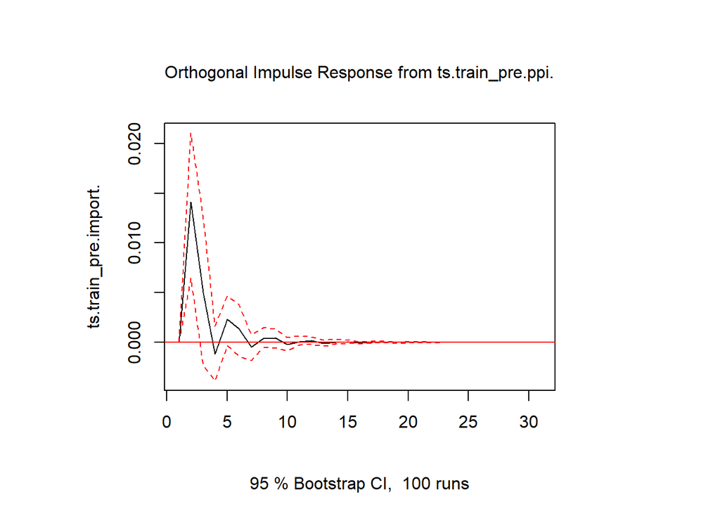

```r
irf.int.pre <- irf(pre_var, response = "ts.train_pre.import.", n.ahead = 30, boot = TRUE)
plot(irf.int.pre)
```

Pre covid: * Export: converges to 0 pretty slowly; impact start with alternating sign (positive and negative alternating) * PPI: a short period of positive impact before periods 5; converges to 0 after period 10.

Post covid: * Export: converges to 0 even more slowly than pre-covid period, but has similar pattern. * PPI: same with export, PPI converges to 0 more slowly than pre-covid period. The 1st and 2nd spikes happen at period 2 and 5. This is likely a lagging response.

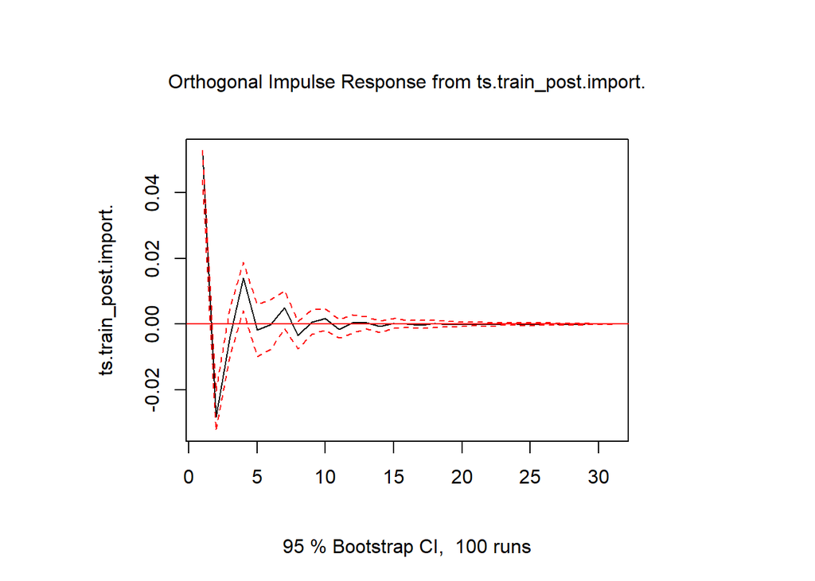

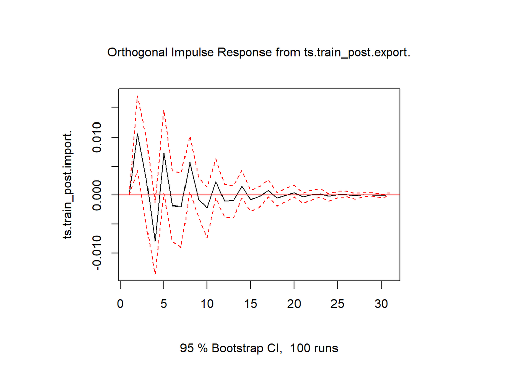

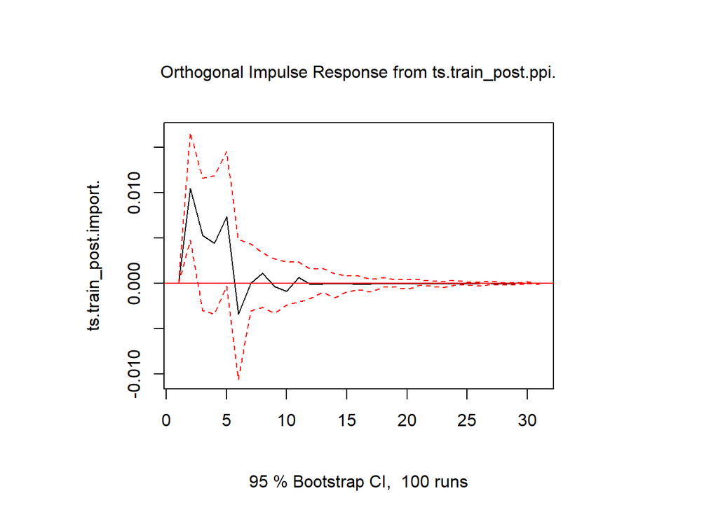

```r
irf.int.post <- irf(post_var, response = "ts.train_post.import.",
                    n.ahead = 30, boot = TRUE)
plot(irf.int.post)
```

## Variance

For both the pre- and post-covid periods, more than 90% of the variation in the import is from shocks to the import itself.

For pre-covid, most of the remaining 10% is from ppi, while for post-covid, the remaining 10% is more equally splited by ppi and export.

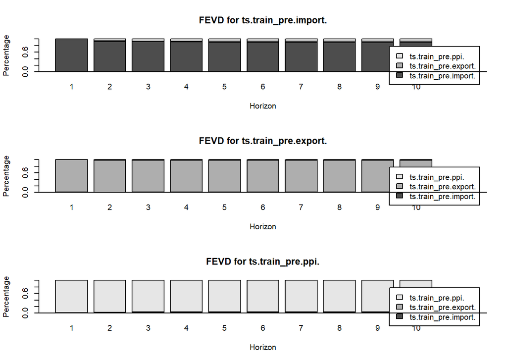

```r
plot(fevd(pre_var))
```

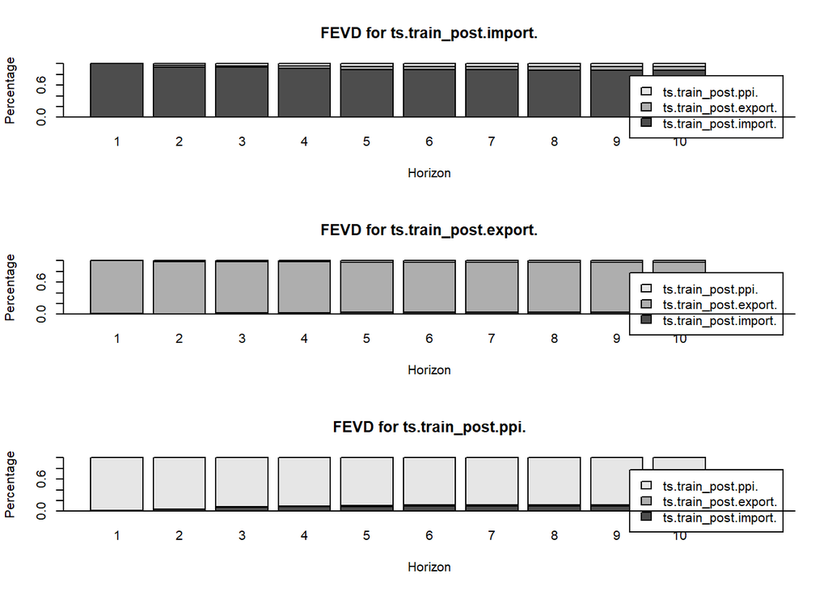

```r
plot(fevd(post_var))
```

```r
library(bruceR)
granger_causality(
  pre_var,
  var.y = NULL,
  var.x = NULL,
  test = c("F", "Chisq"),
  file = NULL,
  check.dropped = FALSE
)
```

```
##
## Granger Causality Test (Multivariate)
##
## F test and Wald χ² test based on VAR(2) model:
## ───────────────────────────────────────────────────────────────────────────────────────────
##                                                      F df1 df2     p     Chisq df     p
## ───────────────────────────────────────────────────────────────────────────────────────────
##  --------------------------------------------
##  ts.train_pre.import. <= ts.train_pre.export.     3.42   2 182  .035 *    6.85  2  .033 *
##  ts.train_pre.import. <= ts.train_pre.ppi.       12.35   2 182 <.001 *** 24.69  2 <.001 ***
##  ts.train_pre.import. <= ALL                      9.12   4 182 <.001 *** 36.47  4 <.001 ***
##  --------------------------------------------
##  ts.train_pre.export. <= ts.train_pre.import.     1.77   2 182  .173      3.55  2  .170
##  ts.train_pre.export. <= ts.train_pre.ppi.        3.59   2 182  .030 *    7.18  2  .028 *
##  ts.train_pre.export. <= ALL                      3.45   4 182  .010 **  13.80  4  .008 **
##  --------------------------------------------
##  ts.train_pre.ppi. <= ts.train_pre.import.        0.75   2 182  .474      1.50  2  .472
##  ts.train_pre.ppi. <= ts.train_pre.export.        0.45   2 182  .636      0.91  2  .636
##  ts.train_pre.ppi. <= ALL                         0.57   4 182  .682      2.29  4  .682
## ───────────────────────────────────────────────────────────────────────────────────────────
```

```r
granger_causality(
  post_var,
  var.y = NULL,
  var.x = NULL,
  test = c("F", "Chisq"),
  file = NULL,
  check.dropped = FALSE
)
```

```
##
## Granger Causality Test (Multivariate)
##
## F test and Wald χ² test based on VAR(5) model:
## ────────────────────────────────────────────────────────────────────────────────────────────
##                                                       F df1 df2     p     Chisq df     p
## ────────────────────────────────────────────────────────────────────────────────────────────
##  ----------------------------------------------
##  ts.train_post.import. <= ts.train_post.export.    3.05   5 206  .011 *   15.26  5  .009 **
##  ts.train_post.import. <= ts.train_post.ppi.       6.08   5 206 <.001 *** 30.40  5 <.001 ***
##  ts.train_post.import. <= ALL                      5.31  10 206 <.001 *** 53.07 10 <.001 ***
##  ----------------------------------------------
##  ts.train_post.export. <= ts.train_post.import.    1.43   5 206  .214      7.17  5  .208
##  ts.train_post.export. <= ts.train_post.ppi.       2.26   5 206  .050 *   11.30  5  .046 *
##  ts.train_post.export. <= ALL                      2.77  10 206  .003 **  27.71 10  .002 **
##  ----------------------------------------------
##  ts.train_post.ppi. <= ts.train_post.import.       2.34   5 206  .043 *   11.72  5  .039 *
##  ts.train_post.ppi. <= ts.train_post.export.       0.74   5 206  .595      3.69  5  .595
##  ts.train_post.ppi. <= ALL                         1.63  10 206  .101     16.27 10  .092 .
## ────────────────────────────────────────────────────────────────────────────────────────────
```